# 📊 ANÁLISE EXPLORATÓRIA DE DADOS (EDA) - VENDAS

## 🎯 1. Objetivo

Este projeto tem como objetivo realizar uma Análise Exploratória de Dados (EDA) sobre o histórico de vendas da empresa.

Serão investigados:

Ao final, serão apresentados insights de negócio baseados nos dados.

### Fonte dos dados

- Nome: Sample Sales Data
- Autor: Gus Segura
- Data: Updated 10 years ago
- Endereço: https://www.kaggle.com/datasets/kyanyoga/sample-sales-data
- Níúmero de registros: 2823

## 🛠 2. Bibliotecas utilizadas

```python
# Análise de dados e Computação científica
import pandas as pd
import numpy as np
# Ambiente de execução
import sys
# Visualização
import matplotlib.pyplot as plt
import seaborn as sns
# Manipulação de dataa/hora
from datetime import datetime
```

## 📦 3. Conjunto de dados

```python
file_csv = "/kaggle/input/datasets/kyanyoga/sample-sales-data/sales_data_sample.csv"
```

## 📥 4. Importe de funções auxiliares

Estas funções têm o objetivo de executar códigos sem superlotar o notebook atual.

```python
sys.path.append("/kaggle/input/datasets/jcarlossc/helpers-function")
from helpers import load_csv
from helpers import checklist_quality
from helpers import plot_histograma
from helpers import plot_boxplot
from helpers import plot_sales_month
from helpers import plot_sales_by_productline
from helpers import plot_top_customers
from helpers import plot_revenue_by_country
from helpers import plot_status
from helpers import calculate_kpis
```

## 📥 5. Leitura dos dados

Nesta etapa, carregamos o conjunto de dados.

```python
df = load_csv(file_csv, encoding="latin1")
```

## 📄 6. Visualização inicial dos dados

Abaixo apresentamos as primeiras linhas do dataset para compreender sua estrutura, colunas disponíveis e possíveis inconsistências iniciais.

```python
df.head(5)
```

|  | ORDERNUMBER | QUANTITYORDERED | PRICEEACH | ORDERLINENUMBER | SALES | ORDERDATE | STATUS | QTR_ID | MONTH_ID | YEAR_ID | ... | ADDRESSLINE1 | ADDRESSLINE2 | CITY | STATE | POSTALCODE | COUNTRY | TERRITORY | CONTACTLASTNAME | CONTACTFIRSTNAME | DEALSIZE |
| --- | --- | --- | --- | --- | --- | --- | --- | --- | --- | --- | --- | --- | --- | --- | --- | --- | --- | --- | --- | --- | --- |
| 0 | 10107 | 30 | 95.70 | 2 | 2871.00 | 2/24/2003 0:00 | Shipped | 1 | 2 | 2003 | ... | 897 Long Airport Avenue | NaN | NYC | NY | 10022 | USA | NaN | Yu | Kwai | Small |
| 1 | 10121 | 34 | 81.35 | 5 | 2765.90 | 5/7/2003 0:00 | Shipped | 2 | 5 | 2003 | ... | 59 rue de l'Abbaye | NaN | Reims | NaN | 51100 | France | EMEA | Henriot | Paul | Small |
| 2 | 10134 | 41 | 94.74 | 2 | 3884.34 | 7/1/2003 0:00 | Shipped | 3 | 7 | 2003 | ... | 27 rue du Colonel Pierre Avia | NaN | Paris | NaN | 75508 | France | EMEA | Da Cunha | Daniel | Medium |
| 3 | 10145 | 45 | 83.26 | 6 | 3746.70 | 8/25/2003 0:00 | Shipped | 3 | 8 | 2003 | ... | 78934 Hillside Dr. | NaN | Pasadena | CA | 90003 | USA | NaN | Young | Julie | Medium |
| 4 | 10159 | 49 | 100.00 | 14 | 5205.27 | 10/10/2003 0:00 | Shipped | 4 | 10 | 2003 | ... | 7734 Strong St. | NaN | San Francisco | CA | NaN | USA | NaN | Brown | Julie | Medium |

5 rows × 25 columns

### 6.1 Observações iniciais

- ✅ O dataset contém informações sobre vendas.
- ✅ Há variáveis categóricas(ex: CITY, STATE), numéricas(ex: PRICEEACH) e do tipo data(ex: ORDERDATE).
- ⚠️ Existem valores nulos em várias colunas(TERRITORY, POSTALCODE, STATE, ADDRESSLINE2...).

## 📄 7. Estrutura dos dados

Nesta etapa, analisaremos os tipos de dados, a quantidade de registros, a quantidade e nomes das colunas e memória utilizada.

```python
df.info()
```

```
<class 'pandas.core.frame.DataFrame'>
RangeIndex: 2823 entries, 0 to 2822
Data columns (total 25 columns):
 #   Column            Non-Null Count  Dtype
---  ------            --------------  -----
 0   ORDERNUMBER       2823 non-null   int64
 1   QUANTITYORDERED   2823 non-null   int64
 2   PRICEEACH         2823 non-null   float64
 3   ORDERLINENUMBER   2823 non-null   int64
 4   SALES             2823 non-null   float64
 5   ORDERDATE         2823 non-null   object
 6   STATUS            2823 non-null   object
 7   QTR_ID            2823 non-null   int64
 8   MONTH_ID          2823 non-null   int64
 9   YEAR_ID           2823 non-null   int64
```

[output cut: 17 more lines]

### 7.1 Principais observações

- ✅ O dataset possui 2823 linhas e 25 colunas.
- ✅ Variáveis numéricas estão representadas como `int64` e `float64`.
- ✅ Variáveis categóricas estão como `object` (texto).
- ⚠️ A coluna `ORDERDATE` precisará de conversão para `datetime`.
- ⚠️ As colunas 'ADDRESSLINE2', 'STATE', 'POSTALCODE', 'TERRITORY' estão com valores nulos.

## 📄 8. Dicionário dos nomes das colunas

| Coluna | Descrição |
| --- | --- |
| ORDERNUMBER | Número do pedido |
| QUANTITYORDERED | Quantidade vendida |
| PRICEEACH | Preço unitário |
| ORDERLINENUMBER | Número da linha do pedido |
| SALES | Valor total da venda |
| ORDERDATE | Data do pedido |
| STATUS | Status do pedido |
| QTR_ID | Id do trimestre |
| MONTH_ID | Id do mês |
| YEAR_ID | Id do ano |
| PRODUCTLINE | Categoria do produto |
| MSRP | Preço de venda sugerido pelo fabricante |
| PRODUCTCODE | Código do produto |
| CUSTOMERNAME | Nome do cliente |
| PHONE | Número do telefone do cliente |
| ADDRESSLINE1 | Endereço 1 |
| ADDRESSLINE2 | Endereço 2 |
| CITY | Cidade |
| STATE | Estado |
| POSTALCODE | Código postal |
| COUNTRY | País |
| TERRITORY | Região comercial |
| CONTACTLASTNAME | Sobrenome de contato |
| CONTACTFIRSTNAME | Primeiro nome de contato |
| DEALSIZE | Porte da negociação |

## ✔ 9. Teste de qualidade dos dados

```python
checklist_quality(df, "ORDERDATE")
```

```
{'shape': {'linhas': 2823, 'colunas': 25},
 'nulos': {'total': 5157,
  'colunas': {'ADDRESSLINE2': {'quantidade': 2521, 'percentual': 89.3},
   'STATE': {'quantidade': 1486, 'percentual': 52.64},
   'POSTALCODE': {'quantidade': 76, 'percentual': 2.69},
   'TERRITORY': {'quantidade': 1074, 'percentual': 38.04}}},
 'duplicados': 0,
 'negativos': {'total': 0, 'colunas': {}},
 'datas': {'tipo_original': 'object',
  'datas_invalidas': 0,
  'data_minima': '2003-01-06 00:00:00',
  'data_maxima': '2005-05-31 00:00:00',
  'datas_futuras': 0}}
```

### 9.1 Conclusão da Qualidade dos Dados

### Pontos Positivos

- ✅ Ausência de registros duplicados.
- ✅ Ausência de valores negativos.
- ✅ Nenhuma data inválida.
- ✅ Nenhuma data futura.
- ✅ Histórico temporal consistente entre 2003 e 2005.

### Pontos de Atenção

- ⚠️ A coluna ORDERDATE está como tipo 'object' e não 'datetime'.
- ⚠️ Alto percentual de valores ausentes em ADDRESSLINE2 (89,3%).
- ⚠️ Percentual relevante de valores ausentes em STATE (52,64%).
- ⚠️ Ausências moderadas em TERRITORY (38,04%).

De modo geral, o conjunto de dados apresenta boa qualidade para análises exploratórias e modelagem estatística. Os principais problemas estão concentrados em variáveis cadastrais, geográficas e tipagem errada para data, que não comprometem as análises de vendas, faturamento, produtos e clientes. A base pode ser considerada adequada para as etapas seguintes do projeto.

## 🔄 10. Conversão de tipo

A coluna data de venda (`ORDERDATE`) será convertida para o tipo `datetime`

```python
df["ORDERDATE"] = pd.to_datetime(df["ORDERDATE"], errors="coerce")
```

## 💰 11. Principais KPIS

```python
calculate_kpis(df)
```

```
==================================================
INDICADORES PRINCIPAIS
==================================================
Receita Total......................: $10,032,628.85
Quantidade de Pedidos..............: 307
Quantidade de Clientes.............: 92
Linhas de Produtos.................: 7
Quantidade de Países...............: 19
Quantidade Vendidas................: 99067
Ticket Médio.......................: $32,679.57
Maior Venda........................: $14,082.80
Menor Venda........................: $482.13
Venda Média........................: $3,553.89
Venda Médiana......................: $3,184.80
Desvio Padrão......................: $1,841.87
Melhor Cliente.....................: Euro Shopping Channel
Maior Receita por Cliente..........: $912,294.11
Receita Média por Cliente..........: $109,050.31
Linha de Produtos mais Vendidos....: Classic Cars
Linha de Produtos com mais Receita.: Classic Cars
Preço Médio........................: $83.66
MSRP Médio.........................: $100.72
```

## 📊 12. Estatísticas Gerais

Resumo das principais variáveis numéricas.

```python
df.describe()
```

|  | ORDERNUMBER | QUANTITYORDERED | PRICEEACH | ORDERLINENUMBER | SALES | ORDERDATE | QTR_ID | MONTH_ID | YEAR_ID | MSRP |
| --- | --- | --- | --- | --- | --- | --- | --- | --- | --- | --- |
| count | 2823.000000 | 2823.000000 | 2823.000000 | 2823.000000 | 2823.000000 | 2823 | 2823.000000 | 2823.000000 | 2823.00000 | 2823.000000 |
| mean | 10258.725115 | 35.092809 | 83.658544 | 6.466171 | 3553.889072 | 2004-05-11 00:16:49.989373056 | 2.717676 | 7.092455 | 2003.81509 | 100.715551 |
| min | 10100.000000 | 6.000000 | 26.880000 | 1.000000 | 482.130000 | 2003-01-06 00:00:00 | 1.000000 | 1.000000 | 2003.00000 | 33.000000 |
| 25% | 10180.000000 | 27.000000 | 68.860000 | 3.000000 | 2203.430000 | 2003-11-06 12:00:00 | 2.000000 | 4.000000 | 2003.00000 | 68.000000 |
| 50% | 10262.000000 | 35.000000 | 95.700000 | 6.000000 | 3184.800000 | 2004-06-15 00:00:00 | 3.000000 | 8.000000 | 2004.00000 | 99.000000 |
| 75% | 10333.500000 | 43.000000 | 100.000000 | 9.000000 | 4508.000000 | 2004-11-17 12:00:00 | 4.000000 | 11.000000 | 2004.00000 | 124.000000 |
| max | 10425.000000 | 97.000000 | 100.000000 | 18.000000 | 14082.800000 | 2005-05-31 00:00:00 | 4.000000 | 12.000000 | 2005.00000 | 214.000000 |
| std | 92.085478 | 9.741443 | 20.174277 | 4.225841 | 1841.865106 | NaN | 1.203878 | 3.656633 | 0.69967 | 40.187912 |

### 💡 12.1 Descrição das Estatísticas Gerais

- ✅ O valor das vendas apresenta elevada variabilidade, indicando coexistência de pedidos pequenos e grandes negociações.
- ✅ A quantidade média vendida é relativamente estável, concentrando-se entre 27 e 43 unidades.
- ✅ Os preços dos produtos estão concentrados em faixas mais altas, sugerindo itens de maior valor agregado.
- ✅ Existem evidências preliminares de sazonalidade, com possível aumento das vendas no segundo semestre.
- ✅ O catálogo apresenta ampla diversidade de preços, permitindo análises por segmento de produto.
- ✅ A presença de vendas muito acima da média sugere a necessidade de investigar clientes, produtos ou períodos responsáveis pelos maiores faturamentos.

## 🔎 13. Análise Univariada

### 13.1 Distribuição das Vendas

Verificação de como as vendas estão distribuídas.

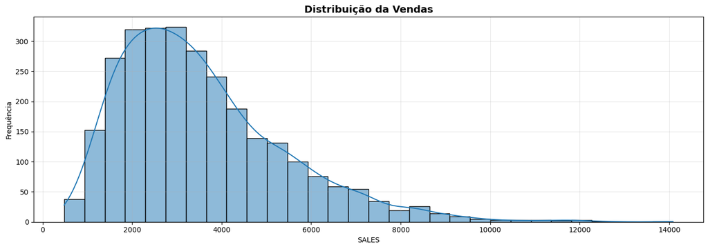

```python
plot_histograma(
    df["SALES"],
    "Distribuição da Vendas",
    30,
    (14, 5)
)
```

### 💡 13.2 Análise da Distribuição das Vendas (SALES)

- ✅ A distribuição das vendas é assimétrica à direita, indicando presença de vendas de alto valor.
- ✅ A maioria das vendas concentra-se entre 2.200 e 4.500.
- ✅ O valor típico de uma venda é próximo de 3.185.
- ✅ Há elevada variabilidade entre as transações.
- ✅ Foram identificados potenciais outliers acima de 7.965, com vendas chegando a 14.083.
- ✅ Esses grandes pedidos podem representar clientes ou produtos com forte impacto no faturamento da empresa.

### 13.3 Distribuição do Preço Unitário

Verificação de como os preços estão distribuídas.

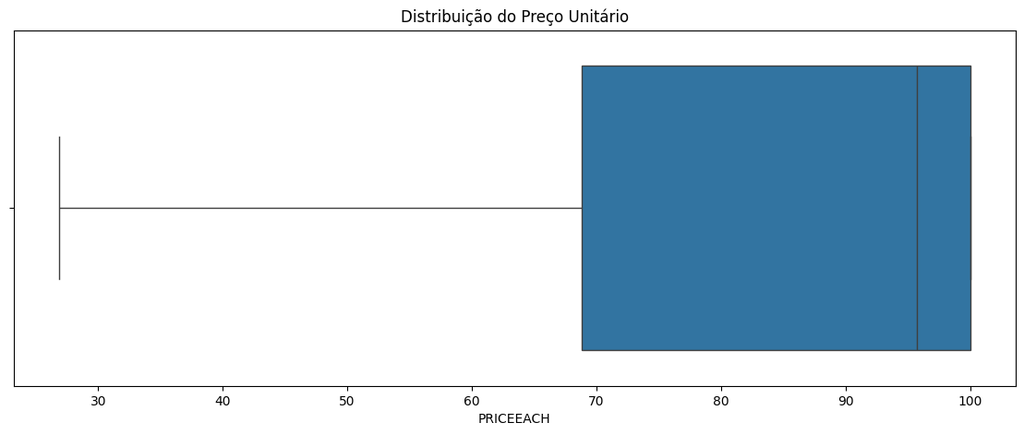

```python
plot_boxplot(
    df["PRICEEACH"],
    "Distribuição do Preço Unitário",
    figsize = (14,5)
)
```

### 💡 13.4 Interpretação do Boxplot — Preço Unitário

A variável PRICEEACH (Preço unitário) apresenta comportamento bastante concentrado em valores próximos ao limite superior de preço.

Principais observações:

- ✅ Os preços variam entre 26,88 e 100,00.
- ✅ A metade dos produtos possui preço acima de 95,70.
- ✅ 75% dos registros possuem preço igual ou inferior a 100,00.
- ✅ Não foram identificados outliers.
- ✅ Existe concentração de produtos em uma faixa de preço premium.

### Insight de negócio

A empresa trabalha predominantemente com produtos de maior valor agregado. A concentração dos preços próximos a 100,00 sugere uma estratégia comercial voltada para produtos premium ou uma política de descontos que limita os preços praticados a esse valor máximo.

## 📈 14. Análise Temporal

### 14.1 Evolução Mensal das Vendas

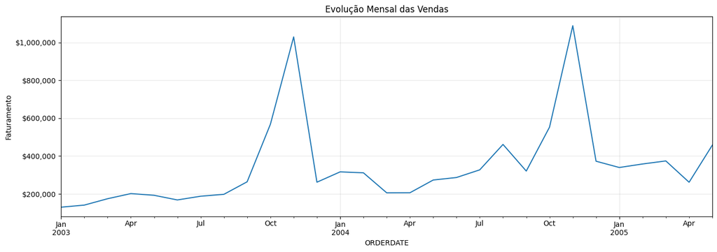

```python
plot_sales_month(
    df,
    "ORDERDATE",
    "SALES",
    "Evolução Mensal das Vendas",
    "Faturamento",
    (14,5)
)
```

### 💡 14.2 Interpretação do Gráfico de Evolução Mensal das Vendas

### Visão Geral

O gráfico apresenta a evolução do faturamento mensal entre janeiro de 2003 e maio de 2005. Observa-se um comportamento não linear, com períodos de estabilidade intercalados por picos expressivos de vendas.

### Tendência Geral

Ao longo do período analisado, o faturamento apresenta uma tendência de crescimento moderado, especialmente entre 2003 e 2004.

A empresa mantém um volume relativamente estável de vendas recorrentes, mas parte relevante da receita é impulsionada por períodos específicos de alta demanda.

### Sazonalidade

O aspecto mais evidente do gráfico é a ocorrência de picos nos meses finais de cada ano.

Esse padrão pode estar relacionado a:

- Compras de final de ano;
- Campanhas promocionais;
- Planejamento orçamentário dos clientes;
- Datas comemorativas e períodos festivos.

### Principais Insights

- ✅ Existe forte evidência de sazonalidade anual.
- ✅ Os maiores faturamentos ocorrem entre outubro e novembro.
- ✅ Novembro é consistentemente o melhor mês de vendas.
- ✅ O faturamento mensal apresenta elevada variabilidade.
- ✅ Grande parte da receita anual parece concentrar-se no último trimestre.
- ✅ Os anos de 2003 e 2004 apresentam padrões temporais semelhantes, reforçando a hipótese de sazonalidade.

### Conclusão

A análise temporal revela que o negócio possui um comportamento sazonal bem definido, com forte concentração das vendas nos meses finais do ano. Os picos observados em novembro de 2003 e 2004 indicam que esse período é crítico para a geração de receita da empresa. Estratégias comerciais, planejamento de estoque e campanhas de marketing devem priorizar os meses que antecedem esse pico de demanda, maximizando o aproveitamento da sazonalidade identificada.

## 📦 15. Análise por Produto

### 15.1 Receita por Linha de Produto

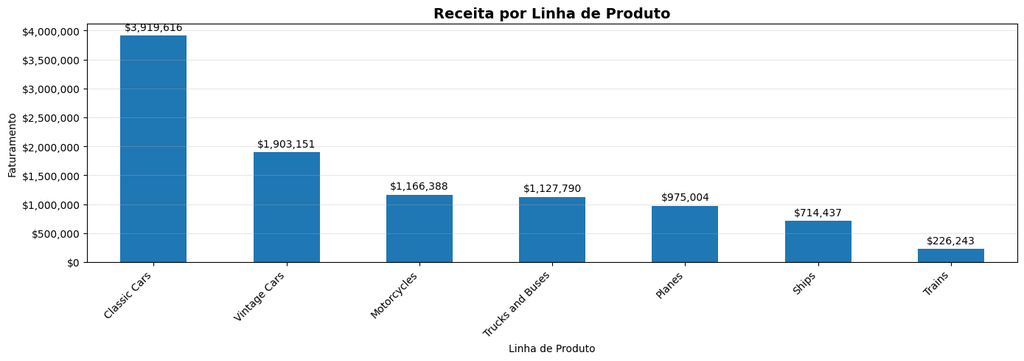

```python
plot_sales_by_productline(
    df,
    "PRODUCTLINE",
    "SALES",
    "Receita por Linha de Produto",
    "Faturamento",
    (14, 5)
)
```

### 💡 15.2 Interpretação do Gráfico de Receita por linha de Produtos

### Principais insights

- ✅ Classic Cars é a categoria líder, respondendo pela maior parcela da receita da empresa.
- ✅ Existe uma alta dependência de poucas categorias, especialmente Classic Cars e Vintage Cars.
- ✅ As categorias intermediárias (Motorcycles, Trucks and Buses e Planes) apresentam desempenho semelhante e podem representar oportunidades de crescimento.
- ✅ Trains possui baixa participação, podendo demandar uma análise mais aprofundada para identificar causas como baixa demanda, oferta limitada ou estratégia comercial inadequada.
- ✅ A concentração da receita sugere que a empresa deve monitorar riscos associados à dependência excessiva de uma única linha de produtos.

### Conclusão

A análise revela que o faturamento da empresa é fortemente impulsionado pela linha Classic Cars, que se destaca amplamente das demais categorias. Embora essa liderança represente uma vantagem competitiva, a elevada concentração da receita pode aumentar a exposição a riscos de mercado. Portanto, estratégias voltadas ao fortalecimento das categorias intermediárias podem contribuir para uma distribuição mais equilibrada da receita e maior sustentabilidade do negócio no longo prazo.

## 👥 16. Análise de Clientes

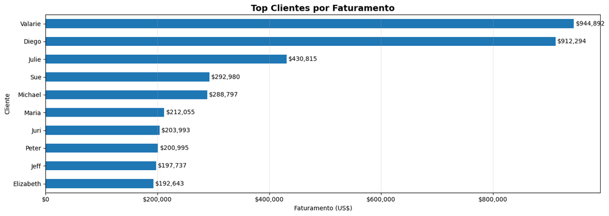

```python
plot_top_customers(
    df,
    "CONTACTFIRSTNAME",
    "SALES",
    10,
    "Top Clientes por Faturamento",
    (14, 5)
)
```

## 🌍 17. Análise Geográfica

### 17.1 Receita por País

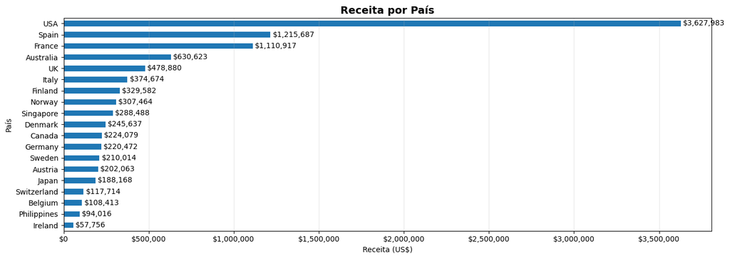

```python
plot_revenue_by_country(
    df,
    "COUNTRY",
    "SALES",
    "Receita por País",
    (14, 5)
)
```

### 💡 17.2 Interpretação do Gráfico Receita por País

### Principais insights

- ✅ Os Estados Unidos são o principal mercado da empresa, representando a maior parcela da receita total.
- ✅ Há uma elevada concentração do faturamento nos três primeiros países (USA, Espanha e França).
- ✅ O mercado americano gera aproximadamente três vezes mais receita do que a Espanha, segunda colocada no ranking.
- ✅ Austrália, Reino Unido e Itália formam um grupo intermediário com potencial para expansão comercial.
- ✅ Os países com menor participação podem representar oportunidades de crescimento por meio de estratégias de marketing, vendas ou ampliação da presença local.

### Conclusão

A análise demonstra que a receita da empresa possui forte dependência do mercado norte-americano, que concentra uma parcela significativa do faturamento global. Embora essa liderança indique uma posição consolidada nos Estados Unidos, a elevada concentração em poucos países pode aumentar a exposição a riscos econômicos ou mudanças de demanda nesses mercados. Nesse contexto, iniciativas voltadas ao fortalecimento dos mercados intermediários e à expansão da atuação em países com menor participação podem contribuir para uma distribuição mais equilibrada da receita e para a sustentabilidade do crescimento da empresa.

## 📊 18. Análise de Status

### 18.1 Distribuição dos Pedidos

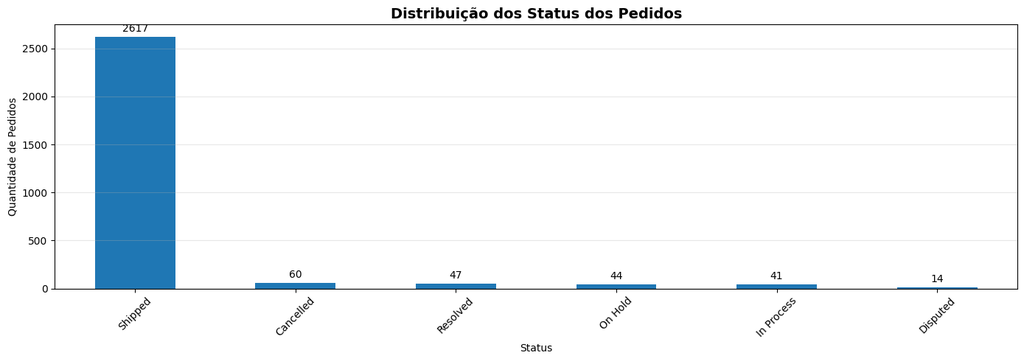

```python
plot_status(
    df,
    "STATUS",
    "Distribuição dos Status dos Pedidos",
    (14, 5)
)
```

### 💡 18.2 Interpretação do Gráfico da Distribuição de Status dos Pedidos

### Principais insights

- ✅ A grande maioria dos pedidos foi concluída com sucesso (Shipped).
- ✅ Os pedidos cancelados representam uma parcela muito pequena do total de transações.
- ✅ Os status On Hold e In Process possuem baixa ocorrência, indicando que há poucos pedidos pendentes ou em andamento.
- ✅ O número reduzido de pedidos em Disputed sugere baixo volume de conflitos comerciais ou reclamações.
- ✅ O cenário geral demonstra eficiência operacional e boa capacidade de atendimento da empresa.

### Conclusão

A análise dos status dos pedidos evidencia um elevado índice de sucesso no processamento das vendas, com predominância absoluta de pedidos enviados aos clientes. Os baixos volumes de cancelamentos, disputas e pedidos pendentes reforçam a eficiência dos processos internos e a qualidade do atendimento prestado. De forma geral, os resultados indicam uma operação estável, com baixo nível de ocorrências que possam impactar negativamente a experiência do cliente ou a geração de receita.

## 🚀 19. Insights de Negócio

### 19.1 Conclusão

A Análise Exploratória de Dados (EDA) permitiu compreender o comportamento das vendas sob diferentes perspectivas, identificando padrões relevantes relacionados aos produtos, clientes, mercados e indicadores operacionais.

Os resultados evidenciaram uma elevada concentração da receita na linha de produtos Classic Cars, seguida por Vintage Cars, indicando que essas categorias representam os principais impulsionadores do faturamento da empresa. Do ponto de vista geográfico, os Estados Unidos destacam-se como o mercado de maior relevância, contribuindo com parcela significativa da receita total, enquanto Espanha e França consolidam-se como mercados estratégicos secundários.

A análise dos clientes revelou que uma pequena parcela da carteira é responsável por grande parte do faturamento, evidenciando a importância da gestão do relacionamento com clientes estratégicos e, ao mesmo tempo, a necessidade de diversificação para reduzir riscos decorrentes da concentração da receita.

Em relação ao processo operacional, observou-se que a maioria dos pedidos encontra-se no status Shipped, indicando elevada eficiência na conclusão das vendas e baixa incidência de cancelamentos, disputas e pedidos pendentes.

De forma geral, a EDA permitiu transformar dados brutos em informações relevantes para a tomada de decisão, destacando oportunidades de crescimento, potenciais riscos relacionados à concentração de receita e possíveis direcionamentos para futuras análises preditivas e estratégicas.

## 🔍 20. Contatos

- Autor: Carlos da Costa
- Recife, PE - Brasil
- Telefone: +55 81 99712 9140
- Telegram: @jcarlossc
- Blogger linguagem R: https://informaticus77-r.blogspot.com/
- Blogger linguagem Python: https://informaticus77-python.blogspot.com/
- Email: jcarlossc1977@gmail.com
- Tableau: https://public.tableau.com/app/profile/carlos.da.costa7416/vizzes/
- LinkedIn: [https://www.linkedin.com/in/carlos-da-costa-669252149/](https://informaticus77-python.blogspot.com)
- GitHub: https://github.com/jcarlossc/
- Kaggle: https://www.kaggle.com/jcarlossc/
- Twitter/X: https://x.com/jcarlossc1977/